# Прогнозирование количества заказов такси

Компания такси хочет оптимизировать свою работу в аэропортах и увеличить прибыль за счет привлечения большего количества водителей в период пиковой нагрузки. Для этого ей необходимо уметь прогнозировать количество заказов такси на следующий час.

**Задача:** Разработать систему предсказания количества заказов такси на следующий час с помощью машинного обучения.  
*Требования к качеству модели*: ошибка модели, оцененная по метрике *RMSE*, не должна превышать 48.

**Описание данных** Исторические данные о заказах такси в аэропортах: количество заказов такси для одинаковых промежутков времени в течение определенного периода.

# Содержание

```python
# import libraries
import os
import warnings
warnings.filterwarnings('ignore')

import matplotlib.pyplot as plt
import numpy as np
import pandas as pd
import seaborn as sns

from catboost import CatBoostRegressor
from lightgbm import LGBMRegressor

from sklearn.ensemble import RandomForestRegressor
from sklearn.linear_model import LinearRegression
from sklearn.metrics import mean_squared_error
from sklearn.model_selection import train_test_split, cross_validate, RandomizedSearchCV, TimeSeriesSplit
from sklearn.preprocessing import StandardScaler

from statsmodels.graphics.tsaplots import plot_acf
from statsmodels.tsa.seasonal import seasonal_decompose
```

```python
# display settings
pd.options.display.max_columns = None
pd.set_option('display.max_colwidth', 100)
pd.set_option("display.precision", 4)

%matplotlib inline
```

## Обзор и подготовка данных

```python
# data path
path = os.path.join(os.path.dirname(os.getcwd()), '12_Time series')
```

```python
# reading file
try:
    data = pd.read_csv(os.path.join(path, 'taxi.csv'),
                     index_col=[0], parse_dates=[0])
except:
    data = pd.read_csv('/datasets/taxi.csv',
                       index_col=[0], parse_dates=[0])

# get first 7 rows
data.head(7)
```

| datetime | num_orders |
| --- | --- |
| 2018-03-01 00:00:00 | 9 |
| 2018-03-01 00:10:00 | 14 |
| 2018-03-01 00:20:00 | 28 |
| 2018-03-01 00:30:00 | 20 |
| 2018-03-01 00:40:00 | 32 |
| 2018-03-01 00:50:00 | 21 |
| 2018-03-01 01:00:00 | 7 |

```python
# get information about the data
data.info()
```

```
<class 'pandas.core.frame.DataFrame'>
DatetimeIndex: 26496 entries, 2018-03-01 00:00:00 to 2018-08-31 23:50:00
Data columns (total 1 columns):
 #   Column      Non-Null Count  Dtype
---  ------      --------------  -----
 0   num_orders  26496 non-null  int64
dtypes: int64(1)
memory usage: 414.0 KB
```

```python
 # check for NaN
if data.isna().sum().sum() > 0:
    print('В данных есть пропущенные значения')
else:
    print('В данных нет пропущенных значений')
```

```
В данных нет пропущенных значений
```

```python
# number of rows
len_data = len(data)
```

```python
# check for monotonicity
if data.index.is_monotonic:
    print('Данные расположены в хронологическом порядке')
else:
    print('Даты повторяются или перемешаны')
```

```
Данные расположены в хронологическом порядке
```

*Вывод*: имеются данные о количестве заказов такси каждые 10 минут за период с 1 марта по 31 августа 2018 года, то есть, за 6 месяцев. В данных нет пропусков и повторов, они расположены в хронологическом порядке.

Согласно задаче проекта, необходимо предсказать количество заказов в последующий час, поэтому ресемплируем данные, посчитав сумму заказов для каждого часа.

```python
# resampling, number of orders per hour
data = data.resample('1H').sum()
data.head()
```

| datetime | num_orders |
| --- | --- |
| 2018-03-01 00:00:00 | 124 |
| 2018-03-01 01:00:00 | 85 |
| 2018-03-01 02:00:00 | 71 |
| 2018-03-01 03:00:00 | 66 |
| 2018-03-01 04:00:00 | 43 |

```python
# get information about the data
data.info()
```

```
<class 'pandas.core.frame.DataFrame'>
DatetimeIndex: 4416 entries, 2018-03-01 00:00:00 to 2018-08-31 23:00:00
Freq: H
Data columns (total 1 columns):
 #   Column      Non-Null Count  Dtype
---  ------      --------------  -----
 0   num_orders  4416 non-null   int64
dtypes: int64(1)
memory usage: 69.0 KB
```

```python
print('Количество данных:')
print(f'Исходно (заказов за каждые 10 мин): {len_data}')
print(f'После ресемплинга (заказов за каждый час): {len(data)}')
```

```
Количество данных:
Исходно (заказов за каждые 10 мин): 26496
После ресемплинга (заказов за каждый час): 4416
```

Построим график получившегося временного ряда.

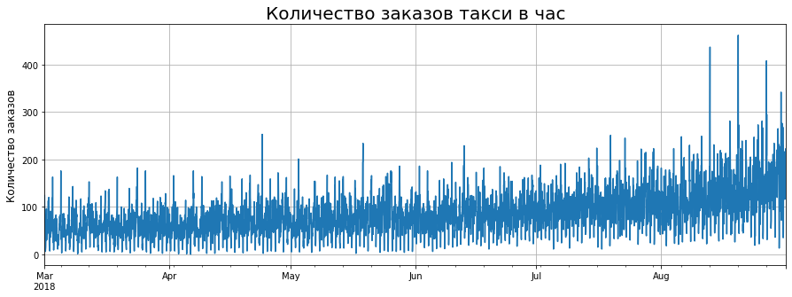

|  | num_orders |
| --- | --- |
| count | 4416.0000 |
| mean | 84.4228 |
| std | 45.0239 |
| min | 0.0000 |
| 25% | 54.0000 |
| 50% | 78.0000 |
| 75% | 107.0000 |
| max | 462.0000 |

```python
# TimeSeries plot
data.plot(figsize=(15, 5), legend = None)
plt.title('Количество заказов такси в час', fontsize=20)
plt.ylabel('Количество заказов', fontsize=12)
plt.xlabel(None)
plt.grid()
plt.show()
data.describe()
```

**Вывод:**

После ресемплирования осталось в 6 раз меньше строк, что корректно для перехода от семплирования по 10 мин к семплированию по 1 часу. В данных наблюдается тренд - постепенное повышение количества заказов такси в аэропорту к лету, в августе повышение самое сильное. Такой тренд логичен - лето и особенно август - время отпусков. Кажется, что есть и сезонность в данных. Можно предположить, что в течении дня есть пиковое время заказов такси (например, вечером и не поздно ночью) и есть время затишья - скорее всего, поздняя ночь и раннее утро. Можно также предположить, что вероятна и сезонность по дням недели - в выходные, пятницу заказов может быть больше. А вот месячную сезонность на имеющихся данных не увидеть.

## Исследовательский анализ данных

Проверим наличие в данных сезонности и тренда.

```python
# decomposition of Time Series, seasonality and trend
decomposed = seasonal_decompose(data)
```

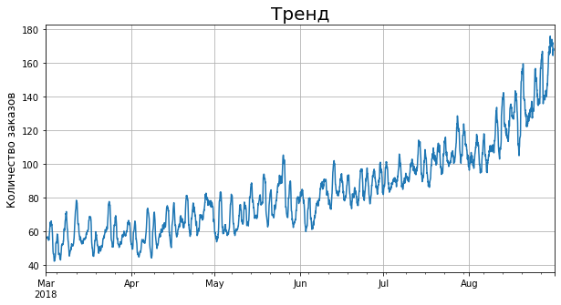

```python
# plot trend
decomposed.trend.plot(figsize=(10, 5))
plt.title('Тренд', fontsize=20)
plt.ylabel('Количество заказов', fontsize=12)
plt.xlabel(None)
plt.grid()
plt.show()
```

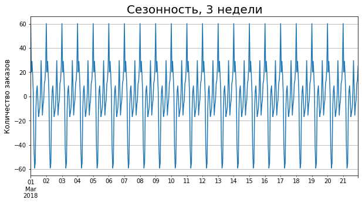

```python
# plot seasonality
decomposed.seasonal['2018-03-01':'2018-03-21'].plot(figsize=(10, 5))
plt.title('Сезонность, 3 недели', fontsize=20)
plt.ylabel('Количество заказов', fontsize=12)
plt.xlabel(None)
plt.grid()
plt.show()
```

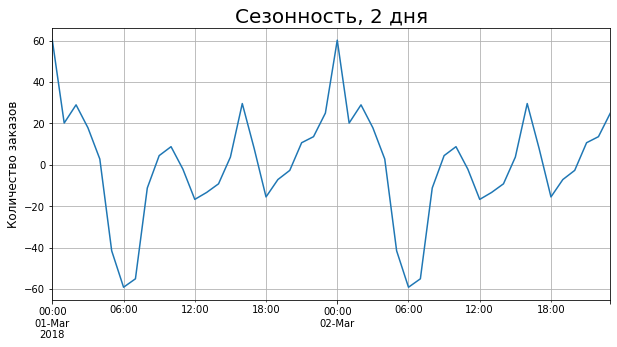

```python
# plot seasonality
decomposed.seasonal['2018-03-01':'2018-03-02'].plot(figsize=(10, 5))
plt.title('Сезонность, 2 дня', fontsize=20)
plt.ylabel('Количество заказов', fontsize=12)
plt.xlabel(None)
plt.grid(which='both')
plt.show()
```

Видно, что в данных есть явный тренд - количество заказов почти линейно растет от марта к сентябрю. Есть также выраженная сезонность по часам. После 2 ночи количество заказов такси резко снижается и к 6 утра достигает минимума. Максимальное количество заказов - около полуночи, есть также пик днем - около 16 часов и утром, около 10. Тренд, все пики и минимумы логичны, объяснимы природой данных.

Посмотрим, наблюдается ли сезонность и какая также с помощью автокорреляции, позволяющей выявить тренд и сезонность. Сначала посмотрим, имеется ли часовая сезонность.

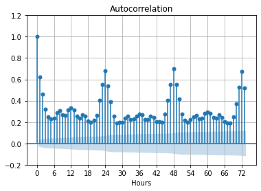

```python
# plot autocorrelation function, shift = 1h, max shift = 73h
plot_acf(data, lags=73, auto_ylims=True)
plt.xticks(range(0, 74, 6))
plt.ylim(-0.2, 1.2)
plt.xlabel('Hours')
plt.grid()
plt.show()
```

Теперь посмотрим, есть ли недельная сезонность.

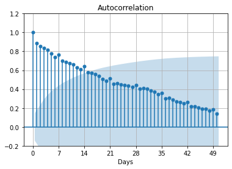

```python
# plot autocorrelation function, shift = 1 day, max shift = 50 days
plot_acf(data.resample('1D').sum(), lags=50)
plt.xticks(range(0, 50, 7))
plt.xlabel('Days')
plt.ylim(-0.2, 1.2)
plt.grid()
plt.show()
```

Для наглядности удалим тренд из данных.

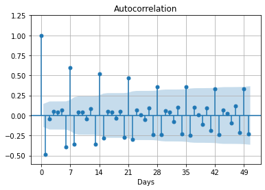

```python
# plot autocorrelation function, shift = 1 day, max shift = 50 days
df = data.resample('1D').sum()
df -= df.shift()
plot_acf(df, lags=50, missing='drop', auto_ylims=True)
plt.xticks(range(0, 50, 7))
plt.xlabel('Days')
plt.grid()
plt.show()
```

Видна явная автокорреляция данных с периодом 24 часа и меньшая с периодом в 12 часов. Это говорит о том, что количество заказов в тот же час в другой день очень схоже. Эта корреляция достаточно сильная - пики выходят за синюю границу (доверительный интервал) на графике.  
Можно также заметить не очень выраженную сезонность по дням недели - автокорреляция на 7, 14 и тд дни немного выше, чем соседние значения.

Наличие тренда в данных говорит об их нестационарности. Кроме этого, кажется, что разброс данных со временем также меняется (в августе он кажется больше), то есть у нас не выполняются оба условия стационарности - неизменность во времени среднего и стандартного отклонения.

Чтобы избавиться от тренда, можно найти разности значений временого ряда. Посмотрим также, как после такого преобразования изменится среднее и стандартное отклонение ряда.

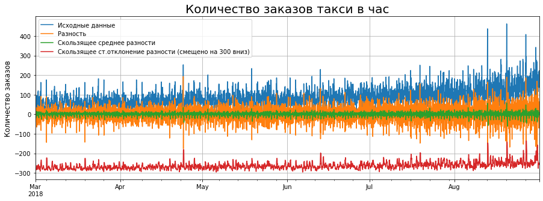

```python
df = data.copy()

# removing trend
df['num_orders_detrend'] = data - data.shift()

# rolling mean, window size=6h
df['mean'] = df['num_orders_detrend'].rolling(6).mean()

# rolling sd, window size=6h
df['std'] = df['num_orders_detrend'].rolling(6).std()-300

# plot data, detrended data, rolling mean and sd
df.plot(figsize=(15, 5))
plt.title('Количество заказов такси в час', fontsize=20)
plt.ylabel('Количество заказов', fontsize=12)
plt.legend(['Исходные данные', 'Разность',
            'Скользящее среднее разности',
            'Скользящее ст.отклонение разности (смещено на 300 вниз)'])
plt.xlabel(None)
plt.grid()
plt.show()
```

Видно, что разность значений временного ряда помогает избавиться от тренда, но никак не влияет на гетероскедастичность - кажется, что в августе увеличивается диапазон разброса стандартных отклонений.

Посмотрим, как будет выглядать временной ряд, если, помимо разности, взять его логарифм.

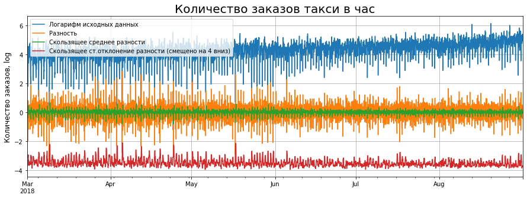

```python
df_log = np.log(data.copy())

# removing trend
df_log['num_orders_detrend'] = df_log - df_log.shift()

# rolling mean, window size=6h
df_log['mean'] = df_log['num_orders_detrend'].rolling(6).mean()

# rolling sd, window size=6h
df_log['std'] = df_log['num_orders_detrend'].rolling(6).std()-4

# plot log_data, detrended log_data, rolling mean and sd
df_log.plot(figsize=(15, 5))
plt.title('Количество заказов такси в час', fontsize=20)
plt.ylabel('Количество заказов, log', fontsize=12)
plt.legend(['Логарифм исходных данных', 'Разность',
            'Скользящее среднее разности',
            'Скользящее ст.отклонение разности (смещено на 4 вниз)'])
plt.xlabel(None)
plt.grid()
plt.show()
```

Логарифмирование временного ряда позволяет снизить разброс стандартного отклонения в августе, но в весенние месяцы он становится больше. Для задачи данного проекта не будем "бороться" с нестационарностью временного ряда и не будем его преобразовывать.

## Создание признаков

Сгенерируем признаки из временного ряда. Нас интересует прогноз на следующий час, кроме этого мы видели сильную сезонность по часам - поэтому добавим признак "час", кроме этого, добавим признак "день недели" - мы видели некоторую сезонность каждые 7 дней. По этим же причинам добавим лаги - предыдущего часа (1), того же часа предыдущего дня (24), и того же часа предыдущей недели (168).

```python
# function to generate new features
def make_features(data, target, lags, rolling_mean_size):
    """Функция принимает на вход датафрейм, в который
    необходимо добавить признаки, название целевой переменной,
    lags - список номеров необходимых лагов и
    rolling_mean_size - значение ширины окна для скользящего среднего.
    Возвращает датафрейм с добавленными переменными:
    временными - значения часа и дня недели, лагами - из lags,
    скользящим средним"""

    data['hour'] = data.index.hour
    data['dayofweek'] = data.index.dayofweek

    for lag in lags:
        data[f'lag_{lag}'] = data[target].shift(lag)

    data['rolling_mean'] = data[target].shift(1).rolling(rolling_mean_size).mean()

    return(data)
```

Как было описано выше, было принято решение добавить лаги со сдвигом на 1 час, на 24 часа и на 168 часов (1 неделя). Скользящее среднее возьмем 6 часов, чтобы не полностью сгладить изменения по часам.

```python
# numbers of lags
lags = [1, 24, 168]
```

```python
# adding the new features
data_added = make_features(data.copy(), 'num_orders', lags, 6)
data_added.head(7)
```

| datetime | num_orders | hour | dayofweek | lag_1 | lag_24 | lag_168 | rolling_mean |
| --- | --- | --- | --- | --- | --- | --- | --- |
| 2018-03-01 00:00:00 | 124 | 0 | 3 | NaN | NaN | NaN | NaN |
| 2018-03-01 01:00:00 | 85 | 1 | 3 | 124.0 | NaN | NaN | NaN |
| 2018-03-01 02:00:00 | 71 | 2 | 3 | 85.0 | NaN | NaN | NaN |
| 2018-03-01 03:00:00 | 66 | 3 | 3 | 71.0 | NaN | NaN | NaN |
| 2018-03-01 04:00:00 | 43 | 4 | 3 | 66.0 | NaN | NaN | NaN |
| 2018-03-01 05:00:00 | 6 | 5 | 3 | 43.0 | NaN | NaN | NaN |
| 2018-03-01 06:00:00 | 12 | 6 | 3 | 6.0 | NaN | NaN | 65.8333 |

Удалим образовавшиеся строки с пропусками.

```python
# removing rows with NaN
print('Количество пропусков:')
print(data_added.isna().sum())
data_added = data_added.dropna()
print(f'После удаления: {data_added.isna().sum().sum()}')
```

```
Количество пропусков:
num_orders        0
hour              0
dayofweek         0
lag_1             1
lag_24           24
lag_168         168
rolling_mean      6
dtype: int64
После удаления: 0
```

**Вывод**:

В имеющихся данных количества заказов такси по часам за полгода имеется положительный почти линейный тренд - количество заказов растет с марта и до конца августа. Наиболее сильный рост наблюдается в августе. Кроме этого, в августе разброс данных также увеличивается. Это позволяет предполагать, что временной ряд нестационарный. В рамках данного проекта не будем принимать меры для корректировки нестанционарности, хотя разность значений временного ряда позволяет избавиться от тренда.

Для прогнозирования временного ряда были добавлены следующие признаки, исходя из наблюдаемой сезонности в данных: скользящее среднее с окном равным 6 часов и лаги предыдущего часа, того же часа предыдущего дня и предыдущей недели.

## Исследование моделей

Для задачи данного проекта протестируем 4 модели - линейную регрессию, случайный лес и две модели градиентного бустинга - CatBoost и LightGBM. Качество моделей оценим по метрике RMSE, а также замерим время обучения и предсказания моделей.

### Разделение датасета

**Выделение целевой переменной**

```python
# target and features
y = data_added['num_orders']
X = data_added.drop('num_orders', axis=1)
X.head(3)
```

| datetime | hour | dayofweek | lag_1 | lag_24 | lag_168 | rolling_mean |
| --- | --- | --- | --- | --- | --- | --- |
| 2018-03-08 00:00:00 | 0 | 3 | 94.0 | 100.0 | 124.0 | 92.3333 |
| 2018-03-08 01:00:00 | 1 | 3 | 143.0 | 121.0 | 85.0 | 99.6667 |
| 2018-03-08 02:00:00 | 2 | 3 | 78.0 | 24.0 | 71.0 | 104.3333 |

**Разделение на обучающую и тестовую выборки**

```python
# train/test split
X_train, X_test, y_train, y_test = train_test_split(
    X, y, test_size=0.1, shuffle=False, random_state=123)

# sizes of training/test data
print('Размеры выборок:')
X_train.shape, X_test.shape, y_train.shape, y_test.shape
```

```
Размеры выборок:
```

```
((3823, 6), (425, 6), (3823,), (425,))
```

```python
print('Обучающая выборка: начало, конец:')
print(X_train.index.min(), X_train.index.max())
print()
print('Тестовая выборка: начало, конец:')
print(X_test.index.min(), X_test.index.max())
```

```
Обучающая выборка: начало, конец:
2018-03-08 00:00:00 2018-08-14 06:00:00

Тестовая выборка: начало, конец:
2018-08-14 07:00:00 2018-08-31 23:00:00
```

### Линейная регрессия

```python
# Create the model
model = LinearRegression()

# Cross-validation
scores_lr = cross_validate(model, X_train, y_train,
                           cv=TimeSeriesSplit(n_splits=8),
                           scoring='neg_root_mean_squared_error')
```

```python
print(f'Среднее количество заказов в час: {y_train.mean():.3f}')

# RMSE
rmse = abs(scores_lr['test_score'].mean())
print(f'RMSE: {rmse:.3f}')

# Training time
time_fit = scores_lr['fit_time'].mean()
print(f'Время обучения: {time_fit:.4f} s')

# Prediction time
time_pred = scores_lr['score_time'].mean()
print(f'Время  предсказания: {time_pred:.4f} s')
```

```
Среднее количество заказов в час: 79.562
RMSE: 22.929
Время обучения: 0.0942 s
Время  предсказания: 0.0080 s
```

Модель линейной регрессии обучается и предсказывает очень быстро, модель ошибается в среднем на 23 заказа для каждого часа, что лучше установленного максимума в 48.

Сохраним характеристики для последующего сравнения с другими моделями.

```python
# pivot table
Model = [str(model)]
TimeFit = [time_fit]
TimePred = [time_pred]
RMSE = [rmse]
```

### Случайный лес

```python
# Create the model
model = RandomForestRegressor(random_state=123)

# Hyperparameters to check
params = {'max_depth': range(3, 20), 'n_estimators': range(10, 100, 10)}
```

```python
# Cross-validation
grid_model = RandomizedSearchCV(model, params, n_jobs=-1,
                                random_state=123,
                                cv=TimeSeriesSplit(n_splits=3),
                                scoring='neg_root_mean_squared_error')

# Fit the model on the training data
grid_model.fit(X_train, y_train)

print(f'Гиперпараметры лучшей модели: {grid_model.best_params_}')
```

```
Гиперпараметры лучшей модели: {'n_estimators': 70, 'max_depth': 7}
```

```python
print(f'Среднее количество заказов в час: {y_train.mean():.3f}')

# RMSE
rmse = abs(grid_model.best_score_)
print(f'RMSE: {rmse:.3f}')

# Training time
time_fit = grid_model.cv_results_['mean_fit_time'][grid_model.best_index_]
print(f'Время обучения: {time_fit:.4f} s')

# Prediction time
time_pred = grid_model.cv_results_['mean_score_time'][grid_model.best_index_]
print(f'Время  предсказания: {time_pred:.4f} s')
```

```
Среднее количество заказов в час: 79.562
RMSE: 24.587
Время обучения: 0.7795 s
Время  предсказания: 0.0365 s
```

```python
# add data to pivot table
Model.append(str(model))
TimeFit.append(time_fit)
TimePred.append(time_pred)
RMSE.append(rmse)
```

Время обучения Случайнго леса больше, чем у линейной регрессии, а качество модели не выше. Лес из 70 деревьев высотой 7 ошибается в среднем примерно на 25 заказов для каждого часа.

### Градиентный бустинг LightGBM

```python
# Create the model
model = LGBMRegressor(random_state=123)

# Hyperparameters to check
params = {'max_depth': range(15, 55, 10),
          'n_estimators': range(10, 100, 10),
          'learning_rate': [0.01, 0.05, 0.1]}
```

```python
# Cross-validation
grid_model = RandomizedSearchCV(model, params, n_jobs=-1,
                                random_state=123,
                                cv=TimeSeriesSplit(n_splits=3),
                                verbose=False,
                                scoring='neg_root_mean_squared_error')

# Fit the model on the training data
grid_model.fit(X_train, y_train)

print(f'Гиперпараметры лучшей модели: {grid_model.best_params_}')
```

```
Гиперпараметры лучшей модели: {'n_estimators': 90, 'max_depth': 35, 'learning_rate': 0.05}
```

```python
print(f'Среднее количество заказов в час: {y_train.mean():.3f}')

# RMSE
rmse = abs(grid_model.best_score_)
print(f'RMSE: {abs(grid_model.best_score_):.3f}')

# Training time
time_fit = grid_model.cv_results_['mean_fit_time'][grid_model.best_index_]
print(f'Время обучения: {time_fit:.4f} s')

# Prediction time
time_pred = grid_model.cv_results_['mean_score_time'][grid_model.best_index_]
print(f'Время  предсказания: {time_pred:.4f} s')
```

```
Среднее количество заказов в час: 79.562
RMSE: 24.311
Время обучения: 0.2827 s
Время  предсказания: 0.0260 s
```

```python
# add data to pivot table
Model.append(str(model))
TimeFit.append(time_fit)
TimePred.append(time_pred)
RMSE.append(rmse)
```

Градиентный бустинг LightGBM из 90 деревьев глубиной до 35 обучается и предсказывает довольно быстро, но ошибается больше простой линейной регрессии, в среднем - на 24 заказа в час.

### Градиентный бустинг CatBoost

```python
# Create the model
model = CatBoostRegressor(silent=True, random_state=123)

# Hyperparameters to check
params = {'max_depth': range(15, 55, 10),
          'n_estimators': range(10, 100, 10),
          'learning_rate': [0.01, 0.05, 0.1]}
```

```python
# Cross-validation
grid_model = RandomizedSearchCV(model, params, n_jobs=-1,
                                random_state=123,
                                cv=TimeSeriesSplit(n_splits=3),
                                scoring='neg_root_mean_squared_error')

# Fit the model on the training data
grid_model.fit(X_train, y_train)


print(f'Гиперпараметры лучшей модели: {grid_model.best_params_}')
```

```
Гиперпараметры лучшей модели: {'n_estimators': 70, 'max_depth': 15, 'learning_rate': 0.05}
```

```python
print(f'Среднее количество заказов в час: {y_train.mean():.3f}')

# RMSE
rmse = abs(grid_model.best_score_)
print(f'RMSE: {abs(grid_model.best_score_):.3f}')

# Training time
time_fit = grid_model.cv_results_['mean_fit_time'][grid_model.best_index_]
print(f'Время обучения: {time_fit:.4f} s')

# Prediction time
time_pred = grid_model.cv_results_['mean_score_time'][grid_model.best_index_]
print(f'Время  предсказания: {time_pred:.4f} s')
```

```
Среднее количество заказов в час: 79.562
RMSE: 26.939
Время обучения: 254.3578 s
Время  предсказания: 0.0527 s
```

```python
# add data to pivot table
Model.append('CatBoostRegressor')
TimeFit.append(time_fit)
TimePred.append(time_pred)
RMSE.append(rmse)
```

Качество предсказания градиентного бустинга CatBoost из 70 деревьев глубиной до 15, хуже, чем у остальных моделей, RMSE=27. При этом время обучения и предсказания у него значительно выше.

### Анализ моделей

Представим результаты анализа моделей в виде сводной таблицы.

```python
# Only model names
Model = [i.split('(', 1)[0] for i in Model]
```

```python
# DataFrame with all characteristics
tbl = pd.DataFrame(
    {'Модель': Model,
     'Время обучения, c': TimeFit,
     'Время предсказания, c': TimePred,
     'Качество, RMSE': RMSE})
tbl.sort_values(by='Качество, RMSE', ascending=True)
```

|  | Модель | Время обучения, c | Время предсказания, c | Качество, RMSE |
| --- | --- | --- | --- | --- |
| 0 | LinearRegression | 0.0942 | 0.0080 | 22.9287 |
| 2 | LGBMRegressor | 0.2827 | 0.0260 | 24.3110 |
| 1 | RandomForestRegressor | 0.7795 | 0.0365 | 24.5871 |
| 3 | CatBoostRegressor | 254.3578 | 0.0527 | 26.9395 |

**Вывод:** По метрике качества RMSE и по скорости работы учшей моделью можно признать линейную регрессию. Протестируем данную модель на тестовой выборке.

## Тестирование

```python
# Create the model
model = LinearRegression()

# Fit the model on the training data
model.fit(X_train, y_train)
```

```
LinearRegression()
```

```python
# Make predictions on the traning data
pred_train = model.predict(X_train)

# Make predictions on the test data
pred_test = model.predict(X_test)
# Adding indexes
predictions = pd.DataFrame(pred_test, index=X_test.index)

# Evaluate the model
rmse_train = mean_squared_error(y_train, pred_train)**0.5
rmse = mean_squared_error(y_test, pred_test)**0.5

print(f'Среднее количество заказов в час: {y_train.mean():.3f}')
print(f'Обучающая выборка RMSE = {rmse_train:.3f}')
print(f'Тестовая выборка RMSE = {rmse:.3f}')
```

```
Среднее количество заказов в час: 79.562
Обучающая выборка RMSE = 22.664
Тестовая выборка RMSE = 35.548
```

На тестовой выборке модель ошибается в среднем на 36 заказов в час, что ниже максимума ошибки = 48.

Посмотрим, какой будет результат, если мы новые значения спрогнозируется просто предыдущим значением ряда.

```python
print(f'Среднее количество заказов в час: {y_train.mean():.3f}')

pred_previous = y_test.shift(fill_value=y_train[-1])
print(f'RMSE: {mean_squared_error(y_test, pred_previous)**0.5:.3f}')
```

```
Среднее количество заказов в час: 79.562
RMSE: 58.820
```

Предсказывать значения предыдущим намного хуже.

Представим результат работы модели графически.

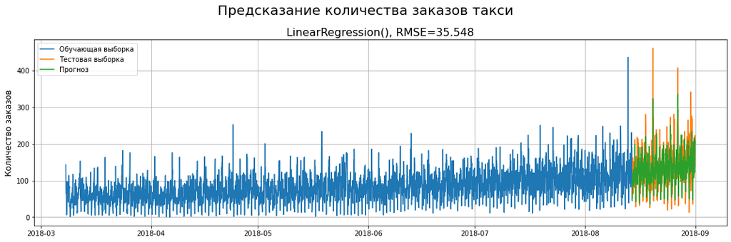

```python
# plot training, test and predicted data
plt.figure(figsize=(15, 5))
plt.plot(y_train)
plt.plot(y_test)
plt.plot(predictions)
plt.suptitle('Предсказание количества заказов такси', fontsize=20)
plt.title(f'{str(model)}, RMSE={rmse:.3f}', fontsize=16)
plt.ylabel('Количество заказов', fontsize=12)
plt.legend(['Обучающая выборка', 'Тестовая выборка', 'Прогноз'],
           loc='upper left')
plt.tight_layout()
plt.grid()
plt.show()
```

Посмотрим отдельно на тестовую выборку и прогноз.

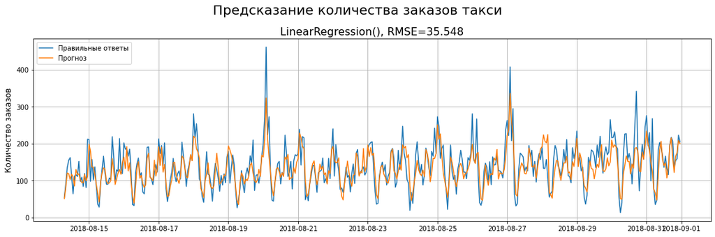

```python
# plot test and predicted data
plt.figure(figsize=(15, 5))
plt.plot(y_test)
plt.plot(predictions)
plt.suptitle('Предсказание количества заказов такси', fontsize=20)
plt.title(f'{str(model)}, RMSE={rmse:.3f}', fontsize=16)
plt.ylabel('Количество заказов', fontsize=12)
plt.legend(['Правильные ответы', 'Прогноз'],
           loc='upper left')
plt.tight_layout()
plt.grid()
plt.show()
```

## Общий вывод:

Для прогнозирования количества заказов такси в аэропорту были использованы данные за полгода, с марта по август 2018. Так как было необходимо сделать прогноз на следующий час, данные были ресемплированы с интервалом в 1 час (исходный интервал был - 10 минут). В данных имеется почти линейный тренд и сильная сезонность по часам, также имеется некоторая сезонность по дням недели. Поэтому, для построения моделей были в качестве признаков были добавлены - значения часа и дня недели, а также лаги предыдущего часа, того же часа предыдущего дня и предыдущей недели.

Были протестированы 4 модели - линейная регрессия, случайный лес и две модели градиентного бустинга - CatBoost и LightGBM. Лучшие показатели качества и скоросто показала модель линейной регрессии, на тестовой выборке метрика RMSE составила 35.5. Кроме этого модель быстро предсказывает и обучается.

При графическом отображении результата видно, что модель довольно неплохо повторяет тестовые данные, однако систематически не точна на "пиках" - на максимумах ниже, а на минимумах выше правильных значений. Причиной может быть изменение тренда в следствие появления/исчезновения какого-то фактора продаж (в такие дни клиенты ведут себя иначе, но это не отражается в заложенных факторах). А обучение происходило без учета этого. Для более точного прогноза модель стоит доработать, провести анализ остатков, попытаться вяснить новый фактор (количество авиарейсов?), также можно взять меньший размер тестовой выборки.